# 16- Dates and Times

Augusto de Souza Cavalcanti

04/05/2021

# 16 Dates and Times

## 16.1 Introduction

Nesse capítulo aprenderemos a lidar com data e tempo no r. Existem várias complexidades que aparecem quando mexemos com isso. Existem vários problemas gerados por questões geopolíticas como meses, anos bissextos, horários de verão e fusos diferentes.

Usaremos o pacote lubridate que facilita mexer com datas e afins. Ele não faz parte do Tidyverse.

## 16.2 Creating Dates and Times

Existem três tipos de formatos de date/time.

Nesse capítulo vamos focar em date e date-time já que o r não possui uma classe nativa para time. Caso seja necessário usar o pacote hms.

Devemos sempre usar o formato de dados mais simples que atende nossas necessidades. Para obter a data ou horário atual podemos usar today() e now().

```r
today()
```

```
## [1] "2021-08-11"
```

```r
now()
```

```
## [1] "2021-08-11 20:51:23 -03"
```

Além disso existem 3 maneiras de criar esses dados.

- A partir de uma string.
- De comoponentes individuais.
- De um objeto existente de date/time.

Eles funcionam das seguintes maneiras.

### 16.2.1 From Strings

Date/time muitas vezes vem como strings. Uma maneira de fazer a transformação é usando as ferramentas do lubridate.

As funções de lubridate usadas tem o nome formado por uma combinação de y (year), m (month), d (day). A combinação na ordem que aparece na sua string. EX:

```r
ymd("2019/03/20")
```

```
## [1] "2019-03-20"
```

```r
ymd("2019x03x20")
```

```
## [1] "2019-03-20"
```

```r
dmy("06/04/2001")
```

```
## [1] "2001-04-06"
```

```r
ymd("2017-01-31")
```

```
## [1] "2017-01-31"
```

```r
mdy("Janeiro 31 2017")
```

```
## [1] "2017-01-31"
```

```r
dmy("28-Junho-2017")
```

```
## [1] "2017-06-28"
```

```r
ymd(20170131)
```

```
## [1] "2017-01-31"
```

```r
mdy(01312017)
```

```
## [1] "2017-01-31"
```

Essas funções também funcionam sem parênteses para números.

ymd() e afins criam datas. Para criar date-times precisamos combinar com um _ e h (hour) e m (minute) e s (second)

```r
ymd_hms("2020-04-06-20-13-15")
```

```
## [1] "2020-04-06 20:13:15 UTC"
```

```r
ymd_hms("2017-01-31 20:11:59")
```

```
## [1] "2017-01-31 20:11:59 UTC"
```

```r
mdy_hm("01/31/2017 08:01")
```

```
## [1] "2017-01-31 08:01:00 UTC"
```

### 16.2.2 From individuals components

Ao ínves de uma string única existem situações que teremos os elementos espalhados em várias colunas. Temos isso em flights.

```r
flights %>% select(year,month,day,hour,minute)
```

```
## # A tibble: 336,776 x 5
##     year month   day  hour minute
##    <int> <int> <int> <dbl>  <dbl>
##  1  2013     1     1     5     15
##  2  2013     1     1     5     29
##  3  2013     1     1     5     40
##  4  2013     1     1     5     45
##  5  2013     1     1     6      0
##  6  2013     1     1     5     58
##  7  2013     1     1     6      0
##  8  2013     1     1     6      0
##  9  2013     1     1     6      0
## 10  2013     1     1     6      0
## # ... with 336,766 more rows
```

Para criar dates e datetimes quando estão dessa maneira com make_date() e make_datetime():

```r
flights %>% select(year,month,day,hour,minute) %>% mutate(data = make_date(year,month,day))
```

```
## # A tibble: 336,776 x 6
##     year month   day  hour minute data
##    <int> <int> <int> <dbl>  <dbl> <date>
##  1  2013     1     1     5     15 2013-01-01
##  2  2013     1     1     5     29 2013-01-01
##  3  2013     1     1     5     40 2013-01-01
##  4  2013     1     1     5     45 2013-01-01
##  5  2013     1     1     6      0 2013-01-01
##  6  2013     1     1     5     58 2013-01-01
##  7  2013     1     1     6      0 2013-01-01
##  8  2013     1     1     6      0 2013-01-01
##  9  2013     1     1     6      0 2013-01-01
## 10  2013     1     1     6      0 2013-01-01
## # ... with 336,766 more rows
```

```r
flights %>% select(year,month,day,hour,minute) %>% mutate(data = make_datetime(year,month,day,hour,minute))
```

```
## # A tibble: 336,776 x 6
##     year month   day  hour minute data
##    <int> <int> <int> <dbl>  <dbl> <dttm>
##  1  2013     1     1     5     15 2013-01-01 05:15:00
##  2  2013     1     1     5     29 2013-01-01 05:29:00
##  3  2013     1     1     5     40 2013-01-01 05:40:00
##  4  2013     1     1     5     45 2013-01-01 05:45:00
##  5  2013     1     1     6      0 2013-01-01 06:00:00
##  6  2013     1     1     5     58 2013-01-01 05:58:00
##  7  2013     1     1     6      0 2013-01-01 06:00:00
##  8  2013     1     1     6      0 2013-01-01 06:00:00
##  9  2013     1     1     6      0 2013-01-01 06:00:00
## 10  2013     1     1     6      0 2013-01-01 06:00:00
## # ... with 336,766 more rows
```

Vamos fazer isso para os outros horários de flights, esses estão em formatos diferentes para extrair o tempo deles podemos usar operadores aritimeticos.

```r
make_datetime_v2 <- function(year,month,day,time){
  make_datetime(year,month,day,time%/%100,time%%100)
}

flightsv2 <- flights %>% filter(!is.na(dep_time) & !is.na(arr_time)) %>% mutate(
  dep_time = make_datetime_v2(year,month,day,dep_time),
  sched_dep_time = make_datetime_v2(year,month,day,sched_dep_time),
  arr_time = make_datetime_v2(year,month,day,arr_time),
  sched_arr_time = make_datetime_v2(year,month,day,sched_arr_time)
) %>% select(year,month,day,origin,dest,ends_with("time"))
```

Podemos visualizar os dados agora ao longo do ano ou ao longo de um dia.

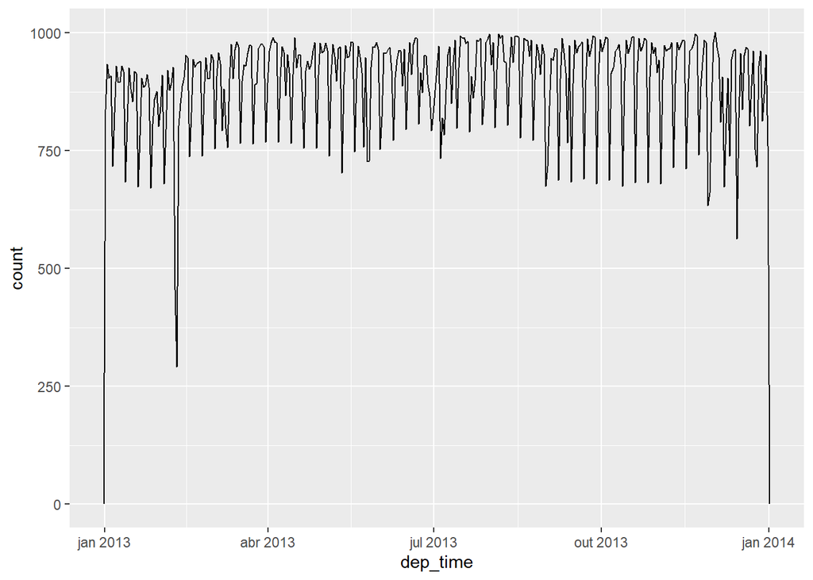

```r
flightsv2 %>%
  ggplot(aes(dep_time)) +
  geom_freqpoly(binwidth = 86400,center=86400/2) # 86400 seconds = 1 day
```

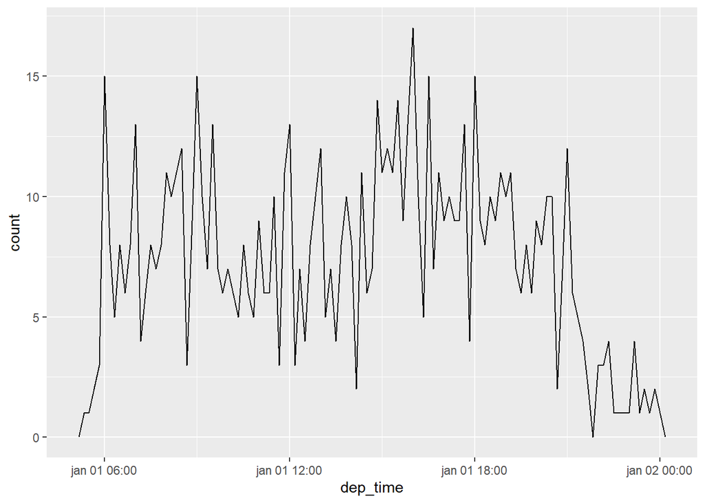

```r
flightsv2 %>%
  filter(dep_time < ymd(20130102)) %>%
  ggplot(aes(dep_time)) +
  geom_freqpoly(binwidth = 600) # 600 s = 10 minutes
```

Quando usamos datetime em um contexto numerico cada 1 = 1 segundo. Então 86400 é um dia.

### 16.2.3 From other Types

Você pode querer mudar entre date_time e date. Para isso usamos as_date_time e as_date.

```r
as_date(now())
```

```
## [1] "2021-08-11"
```

```r
as_datetime(today())
```

```
## [1] "2021-08-11 UTC"
```

As vezes receberemos o horário numericamente como o tempo passado depois de 1970-01-91, “Unix Epoch”. Se o valor está em dias use as_date() se tiver em segundos use as_datetime()

```r
as_datetime(60 * 60 * 10)
```

```
## [1] "1970-01-01 10:00:00 UTC"
```

```r
as_date(365 * 10 + 2)
```

```
## [1] "1980-01-01"
```

### Exercícios 16.2.4

1. O que acontece se tentarmos analisar strings com datas inválidas?

```r
ymd(c("2010-10-10", "bananas"))
```

```
## Warning: 1 failed to parse.
```

```
## [1] "2010-10-10" NA
```

Produz um NA e uma aviso

2. What does the tzone argument to today() do? Why is it important?

Informa qual a zona que queremos o dia. Dado que o dia pode ser diferente entre zonas diferentes. Temos uma lista de locais que podemos fornecer por meio da função OlsonNames()

```r
OlsonNames() %>% str_subset(pattern = "Australia")
```

```
##  [1] "Australia/ACT"         "Australia/Adelaide"    "Australia/Brisbane"
##  [4] "Australia/Broken_Hill" "Australia/Canberra"    "Australia/Currie"
##  [7] "Australia/Darwin"      "Australia/Eucla"       "Australia/Hobart"
## [10] "Australia/LHI"         "Australia/Lindeman"    "Australia/Lord_Howe"
## [13] "Australia/Melbourne"   "Australia/North"       "Australia/NSW"
## [16] "Australia/Perth"       "Australia/Queensland"  "Australia/South"
## [19] "Australia/Sydney"      "Australia/Tasmania"    "Australia/Victoria"
## [22] "Australia/West"        "Australia/Yancowinna"
```

```r
today()
```

```
## [1] "2021-08-11"
```

```r
today(tzone = "Australia/Sydney")
```

```
## [1] "2021-08-12"
```

3. Use the appropriate lubridate function to parse each of the following dates:

```r
d1 <- "January 1, 2010"
d2 <- "2015-Mar-07"
d3 <- "06-Jun-2017"
d4 <- c("August 19 (2015)", "July 1 (2015)")
d5 <- "12/30/14" # Dec 30, 2014
```

```r
mdy(d1)
```

```
## [1] "2010-01-01"
```

```r
ymd(d2)
```

```
## [1] "2015-03-07"
```

```r
dmy(d3)
```

```
## [1] "2017-06-06"
```

```r
mdy(d4)
```

```
## [1] "2015-08-19" "2015-07-01"
```

```r
mdy(d5)
```

```
## [1] "2014-12-30"
```

## 16.3 Date-Time Components

Agora que sabemos como ler e armazenar as estruturas de data e tempo, vamos aprender um pouco sobre o que podemos fazer com elas.

### 16.3.1 Getting Components

Podemos extrair desses formatos informações sozinhas sobre o ano year(), mês month(), dia do mês mday(), dia da semana wday(), dia do ano yday(), hora hour(), minuto minute() e segundo second().

```r
datetime <- ymd_hms("2016-07-08 12:34:56")

year(datetime)
```

```
## [1] 2016
```

```r
month(datetime)
```

```
## [1] 7
```

```r
mday(datetime)
```

```
## [1] 8
```

```r
yday(datetime)
```

```
## [1] 190
```

```r
wday(datetime)
```

```
## [1] 6
```

Para month e wday podemos fornecer label=T para termos o retorno do nome do dia ou mês, podemos fornecer abbr = F para retornar o nome completo.

```r
month(datetime, label = TRUE)
```

```
## [1] jul
## 12 Levels: jan < fev < mar < abr < mai < jun < jul < ago < set < ... < dez
```

```r
wday(datetime, label = TRUE, abbr = FALSE)
```

```
## [1] sexta-feira
## 7 Levels: domingo < segunda-feira < terça-feira < ... < sábado
```

Podemos usar wday para ver que mais voos saem em dias de semana que finais de semana por exemplo.

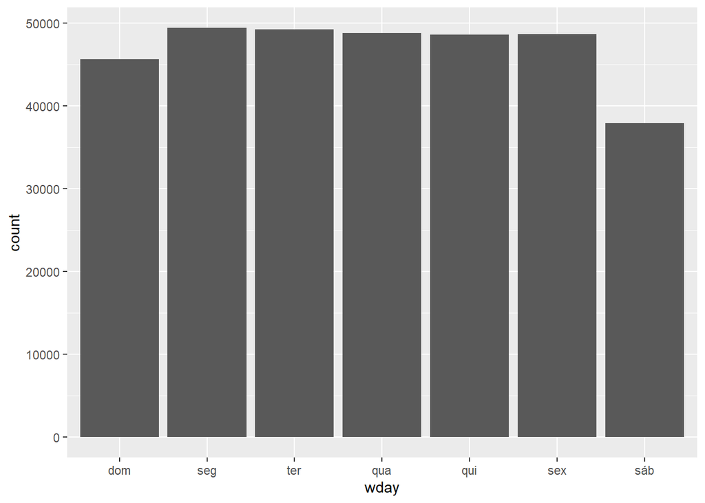

```r
flightsv2 %>%
  mutate(wday = wday(dep_time, label = TRUE)) %>%
  ggplot(aes(x = wday)) +
    geom_bar()
```

### 16.3.2 Rounding

Uma alternativa a fazer um gráfico com os componentes individuais de data é fazer um arredondamento para uma unidade de tempo próxima. floor_date(), round_date() e ceilling_date() fazem isso e recebem um vetor de datas e ajusta para a unidade fornecida.

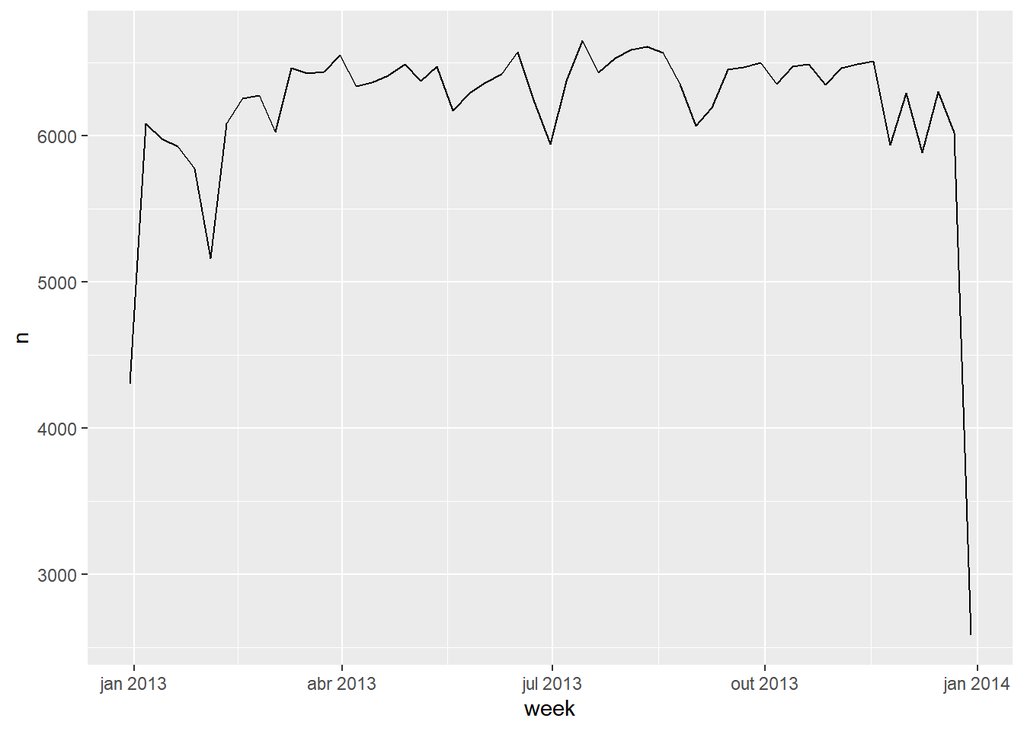

```r
flightsv2 %>%
  count(week = floor_date(dep_time, "week")) %>%
  ggplot(aes(week, n)) +
    geom_line()
```

### 16.3.3 Setting components

Podemos também usar cada função para definir os componentes de date/time.

```r
(datetime <- ymd_hms("2016-07-08 12:34:56"))
```

```
## [1] "2016-07-08 12:34:56 UTC"
```

```r
year(datetime) <- 2020
datetime
```

```
## [1] "2020-07-08 12:34:56 UTC"
```

```r
month(datetime) <- 01
datetime
```

```
## [1] "2020-01-08 12:34:56 UTC"
```

```r
hour(datetime) <- hour(datetime) + 1
datetime
```

```
## [1] "2020-01-08 13:34:56 UTC"
```

Podemos fazer também essa alteração usando update, isso não altera o objeto em si, cria um novo que pode ser salvo por cima caso desejado. Podemos alterar varios componentes de uma vez.

```r
update(datetime, year = 2020, month = 2, mday = 2, hour = 2)
```

```
## [1] "2020-02-02 02:34:56 UTC"
```

Se o valor que passamos é muito grande ele é passado para frente (61 minutos a mais vai retornar 1h e 1min)

```r
ymd("2015-02-01") %>%
  update(mday = 30)
```

```
## [1] "2015-03-02"
```

```r
ymd("2015-02-01") %>%
  update(hour = 400)
```

```
## [1] "2015-02-17 16:00:00 UTC"
```

### Exercícios 16.3.4

1. How does the distribution of flight times within a day change over the course of the year?

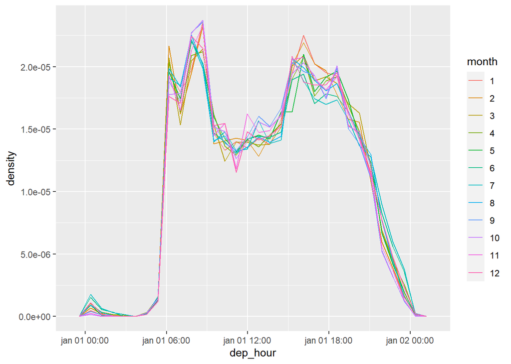

```r
flightsv2 %>% filter(!is.na(dep_time)) %>% mutate(dep_hour = update(dep_time,yday=1),month = factor(month(dep_time))) %>% ggplot(aes(dep_hour,color=month)) + geom_freqpoly(aes(y=..density..))
```

Não muda quase nada.

2. Compare dep_time, sched_dep_time and dep_delay. Are they consistent? Explain your findings.

```r
flights %>% filter(!is.na(dep_time)) %>% transmute(dep_delay,sched_dep_time = make_datetime_v2(year,month,day,sched_dep_time),dep_time =make_datetime_v2(year,month,day,dep_time)) %>% mutate(Correto = dep_time == sched_dep_time + dep_delay*60) %>% summarise(mean(Correto))
```

```
## # A tibble: 1 x 1
##   `mean(Correto)`
##             <dbl>
## 1           0.996
```

Podemos ver que para 99.6% dos voos o tempo está correto. Isso faz com que os tempos estejam correto e os erros são situações espécificas que devem ser analisadas.

3. Compare air_time with the duration between the departure and arrival. Explain your findings. (Hint: consider the location of the airport.)

```r
flights %>% transmute(dep_time = make_datetime_v2(year,month,day,dep_time),arr_time = make_datetime_v2(year,month,day,arr_time),air_time) %>% mutate(igual = arr_time == dep_time + 60*air_time) %>% summarise(mean(igual,na.rm=T))
```

```
## # A tibble: 1 x 1
##   `mean(igual, na.rm = T)`
##                      <dbl>
## 1                 0.000599
```

Podemos ver que os horários quase nunca estão certos. Isso acontece pois o horários não está levando em consideração a mudança de fuso. Os que estão certos provavelmente pertencem ao mesmo fuso-horario.

4. How does the average delay time change over the course of a day? Should you use dep_time or sched_dep_time? Why?

Devemos usar sched_dep_time pois queremos o delay baseado no horario que os voos foram marcados não o horário que saíram.

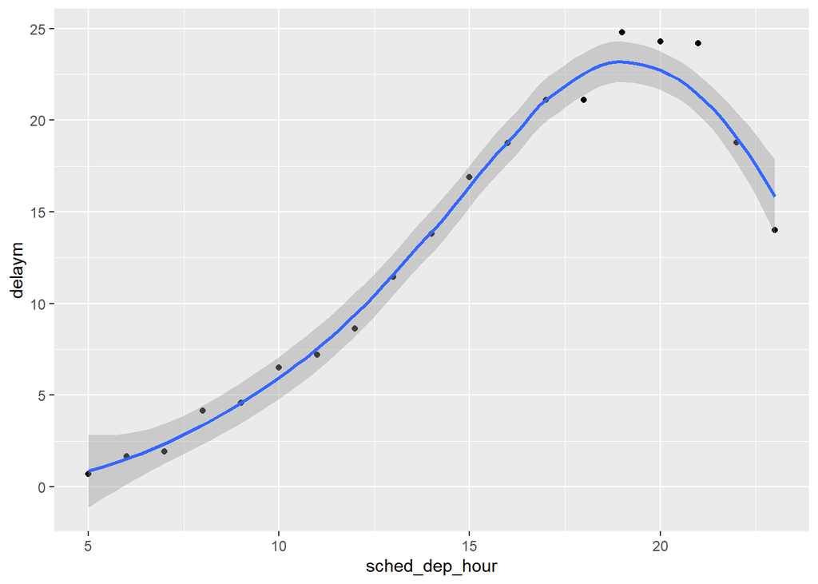

```r
flights %>% filter(!is.na(dep_time)) %>% mutate(sched_dep_time =make_datetime_v2(year,month,day,sched_dep_time)) %>%
  mutate(sched_dep_hour = hour(sched_dep_time)) %>% group_by(sched_dep_hour) %>% summarise(delaym = mean(dep_delay))%>%   ggplot(aes(sched_dep_hour,delaym)) + geom_point() + geom_smooth()
```

5. On what day of the week should you leave if you want to minimise the chance of a delay?

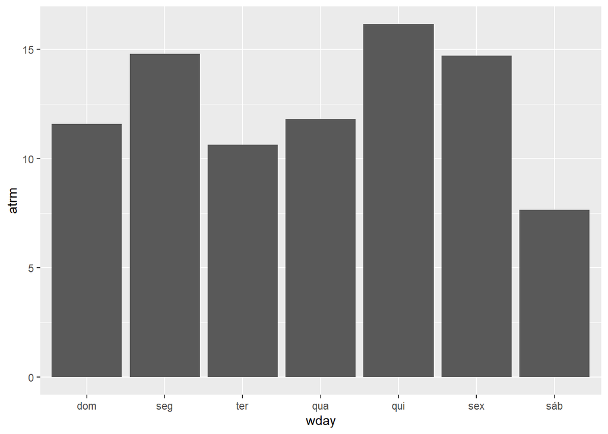

```r
flights %>% mutate(wday = make_datetime_v2(year,month,day,sched_dep_time) %>% wday(label = T)) %>% group_by(wday) %>% summarise(atrm = mean(dep_delay,na.rm=T)) %>%  ggplot(aes(wday,atrm)) + geom_bar(stat="identity")
```

Podemos ver que sábado é o melhor dia para viajar caso não queira atraso.

6. `What makes the distribution of diamonds$carat and flights$sched_dep_time similar?`

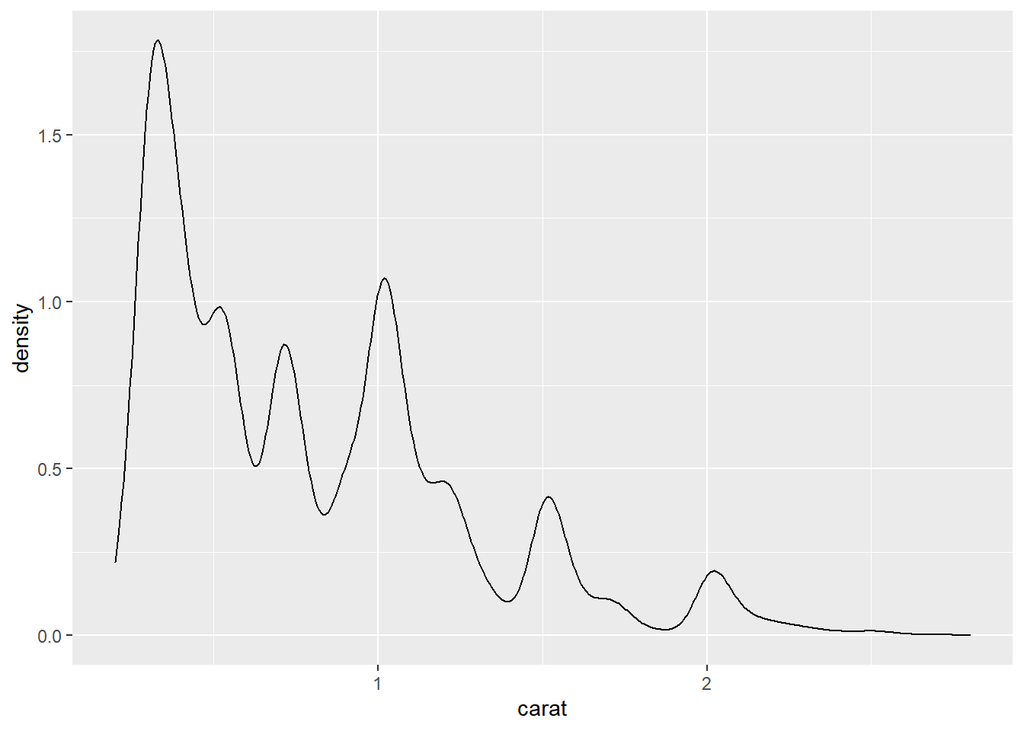

```r
diamonds %>% filter(carat<3) %>% ggplot(aes(carat)) + geom_density()
```

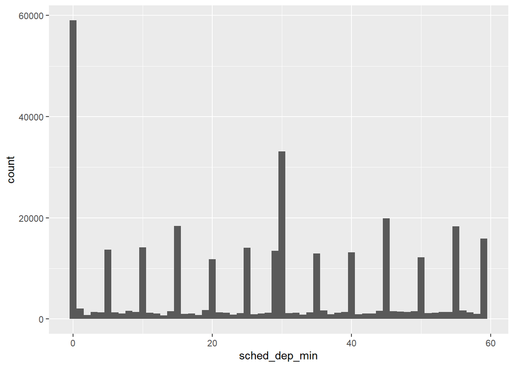

```r
flightsv2 %>% mutate(sched_dep_min = minute(sched_dep_time)) %>% ggplot(aes(sched_dep_min)) + geom_histogram(binwidth = 1)
```

Os dois indicam que existe um arredondamento para valores “bonitos”.

## 16.4 Time Spans

Agora vamos aprender sobre como aritimética com datas funciona, incluido subtração, soma e divisão. Vamos apresentar algumas classes que representam espaçoes de tempo.

- durations, que representam um número exato de segundos.
- periods, que representam unidades humanas como semanas e meses.
- intervals, que representam um ponto inicial e final.

### 16.4.1 Durations

No r, quando subtraimos duas datas recebemos um objeto difftime.

```r
# Quão velho eu sou?
idade <- today() - ymd(20010406)
idade
```

```
## Time difference of 7432 days
```

Um objeto difftime podea armazenar em segundos, minutos, horas, dias ou semanas. Isso pode ficar um pouco complicato então o lubridate fornece durtaion(que sempre usa segundos).

```r
as.duration(idade)
```

```
## [1] "642124800s (~20.35 years)"
```

Durations vem com várias possibilidades de serem construídas úteis.

```r
dseconds(15)
```

```
## [1] "15s"
```

```r
dminutes(10)
```

```
## [1] "600s (~10 minutes)"
```

```r
dhours(c(12, 24))
```

```
## [1] "43200s (~12 hours)" "86400s (~1 days)"
```

```r
ddays(0:5)
```

```
## [1] "0s"                "86400s (~1 days)"  "172800s (~2 days)"
## [4] "259200s (~3 days)" "345600s (~4 days)" "432000s (~5 days)"
```

```r
dweeks(3)
```

```
## [1] "1814400s (~3 weeks)"
```

```r
dyears(1)
```

```
## [1] "31557600s (~1 years)"
```

Podemos multiplicar e adicionar durações.

```r
2 * dyears(1)
```

```
## [1] "63115200s (~2 years)"
```

```r
dyears(1) + dweeks(12) + dhours(15)
```

```
## [1] "38869200s (~1.23 years)"
```

Voce pode adicionar e subtrair durações de dias.

```r
tomorrow <- today() + ddays(1)
last_year <- today() - dyears(1)
```

Porém isso pode causar problemas, ex:

```r
one_pm <- ymd_hms("2016-03-12 13:00:00", tz = "America/New_York")

one_pm
```

```
## [1] "2016-03-12 13:00:00 EST"
```

```r
one_pm + ddays(1)
```

```
## [1] "2016-03-13 14:00:00 EDT"
```

Como durations apenas altera os segundos, quando temos situações especiais, como um horário de verão alterando o horário somamos 24hrs mas só se passarão 23 na realidade.

### 16.4.2 Periods

Para resolver esse problema temos periods. Esses são espaços de tempo porém não tem uma largura fixa neles, eles funcionam com tempo humano como dias e meses.

```r
one_pm
```

```
## [1] "2016-03-12 13:00:00 EST"
```

```r
one_pm + days(1)
```

```
## [1] "2016-03-13 13:00:00 EDT"
```

Assim como durations, também podem ser criados com várias funções que facilitam.

```r
seconds(15)
```

```
## [1] "15S"
```

```r
minutes(10)
```

```
## [1] "10M 0S"
```

```r
hours(c(12, 24))
```

```
## [1] "12H 0M 0S" "24H 0M 0S"
```

```r
days(7)
```

```
## [1] "7d 0H 0M 0S"
```

```r
months(1:6)
```

```
## [1] "1m 0d 0H 0M 0S" "2m 0d 0H 0M 0S" "3m 0d 0H 0M 0S" "4m 0d 0H 0M 0S"
## [5] "5m 0d 0H 0M 0S" "6m 0d 0H 0M 0S"
```

```r
weeks(3)
```

```
## [1] "21d 0H 0M 0S"
```

```r
years(1)
```

```
## [1] "1y 0m 0d 0H 0M 0S"
```

Podemos adicionar e multiplicar periods.

```r
10 * (months(6) + days(1))
```

```
## [1] "60m 10d 0H 0M 0S"
```

```r
days(50) + hours(25) + minutes(2)
```

```
## [1] "50d 25H 2M 0S"
```

Podemos também adicionar a datas.

```r
# A leap year
ymd("2016-01-01") + dyears(1)
```

```
## [1] "2016-12-31 06:00:00 UTC"
```

```r
ymd("2016-01-01") + years(1)
```

```
## [1] "2017-01-01"
```

```r
# Horário de Verão
one_pm + ddays(1)
```

```
## [1] "2016-03-13 14:00:00 EDT"
```

```r
one_pm + days(1)
```

```
## [1] "2016-03-13 13:00:00 EDT"
```

Podemos usar isso para consertar algo em flights. Existem voos que informam que chegaram antes de sua saída. Isso acontece com voos que chegaram em outros dias (dps meia noite).

```r
flightsv2 <- flightsv2 %>%
  mutate(
    overnight = arr_time < dep_time,
    arr_time = arr_time + days(overnight * 1),
    sched_arr_time = sched_arr_time + days(overnight * 1)
  )
```

```r
flightsv2 %>% filter(overnight,arr_time < dep_time)
```

```
## # A tibble: 0 x 11
## # ... with 11 variables: year <int>, month <int>, day <int>, origin <chr>,
## #   dest <chr>, dep_time <dttm>, sched_dep_time <dttm>, arr_time <dttm>,
## #   sched_arr_time <dttm>, air_time <dbl>, overnight <lgl>
```

### 16.4.3 Intervals

Mas o que years(1)/days(1) retrona? Isso depende do ano, se for bissexto 365, se não 365. O lubridate não tem informação suficiente para fornecer a resposta. Então ele fornece uma estimativa.

```r
years(1) / days(1)
```

```
## [1] 365.25
```

Se quisermos algo mais preciso usar um interval. Um intervalo é exatamente a duração entre uma data inicial e uma final.

```r
next_year <- today() + years(1)
(today() %--% next_year) / ddays(1)
```

```
## [1] 365
```

Para saber quantos períodos cabem em um intervalo temos que usar uma divisão de inteiros.

```r
(today() %--% next_year) %/% days(1)
```

```
## [1] 365
```

### Exercícios 16.4.5

1. Why is there months() but no dmonths()?

Durações de meses variam demais, por mais que anos também variam não é a mesma coisa.

2. Explain days(overnight * 1) to someone who has just started learning R. How does it work?

Como overnight contém TRUE ou FALSE, que assumem (1 ou 0), quando um voo passar de meia noite somamos 1 dia, quando não passar não somamos.

3. Create a vector of dates giving the first day of every month in 2015. Create a vector of dates giving the first day of every month in the current year.

```r
ymd(20150101) + months(0:11)
```

```
##  [1] "2015-01-01" "2015-02-01" "2015-03-01" "2015-04-01" "2015-05-01"
##  [6] "2015-06-01" "2015-07-01" "2015-08-01" "2015-09-01" "2015-10-01"
## [11] "2015-11-01" "2015-12-01"
```

```r
ymd(20210101) + months(0:11)
```

```
##  [1] "2021-01-01" "2021-02-01" "2021-03-01" "2021-04-01" "2021-05-01"
##  [6] "2021-06-01" "2021-07-01" "2021-08-01" "2021-09-01" "2021-10-01"
## [11] "2021-11-01" "2021-12-01"
```

4. Write a function that given your birthday (as a date), returns how old you are in years.

```r
anosniver <- function(nascimento){
  idade <- (nascimento %--% today()) %/% years(1)
  return(idade)
}

anosniver(dmy(06042001))
```

```
## [1] 20
```

## 16.5 Time Zones

Fusos muitas vezes não importantes para análises de dados, porém quando são eles são trabalhasos de lidar por problemas geopoliticos de horarios de verão e outros fatores que mudam com frequência. Mas tambêm por dificuldades de manipulação no r. Voce pode descobrir a zona do seu sistema e listar todas zonas usadas pelo r.

```r
Sys.timezone()
```

```
## [1] "America/Sao_Paulo"
```

```r
OlsonNames()
```

```
##   [1] "Africa/Abidjan"                   "Africa/Accra"
##   [3] "Africa/Addis_Ababa"               "Africa/Algiers"
##   [5] "Africa/Asmara"                    "Africa/Asmera"
##   [7] "Africa/Bamako"                    "Africa/Bangui"
##   [9] "Africa/Banjul"                    "Africa/Bissau"
##  [11] "Africa/Blantyre"                  "Africa/Brazzaville"
##  [13] "Africa/Bujumbura"                 "Africa/Cairo"
##  [15] "Africa/Casablanca"                "Africa/Ceuta"
##  [17] "Africa/Conakry"                   "Africa/Dakar"
##  [19] "Africa/Dar_es_Salaam"             "Africa/Djibouti"
##  [21] "Africa/Douala"                    "Africa/El_Aaiun"
##  [23] "Africa/Freetown"                  "Africa/Gaborone"
##  [25] "Africa/Harare"                    "Africa/Johannesburg"
##  [27] "Africa/Juba"                      "Africa/Kampala"
##  [29] "Africa/Khartoum"                  "Africa/Kigali"
```

[output cut: 284 more lines]

Timezones são atributos de date_time que só controlam a impressão.

```r
(x1 <- ymd_hms("2015-06-01 12:00:00", tz = "America/New_York"))
```

```
## [1] "2015-06-01 12:00:00 EDT"
```

```r
(x2 <- ymd_hms("2015-06-01 18:00:00", tz = "Europe/Copenhagen"))
```

```
## [1] "2015-06-01 18:00:00 CEST"
```

```r
(x3 <- ymd_hms("2015-06-02 04:00:00", tz = "Pacific/Auckland"))
```

```
## [1] "2015-06-02 04:00:00 NZST"
```

Podemos verificar que eles são iguais.

```r
x1 - x2
```

```
## Time difference of 0 secs
```

```r
x1 - x3
```

```
## Time difference of 0 secs
```

Podemos mudar os fusos de duas maneiras:

Quando concatenamos perdemos os fusos.

```r
x4 <- c(x1, x2, x3)
x4
```

```
## [1] "2015-06-01 12:00:00 EDT" "2015-06-01 12:00:00 EDT"
## [3] "2015-06-01 12:00:00 EDT"
```

```r
# Keep the instant in time the same, and change how it’s displayed. Use this when the instant is correct, but you want a more natural display.
x4a <- with_tz(x4, tzone = "Australia/Lord_Howe")
x4a
```

```
## [1] "2015-06-02 02:30:00 +1030" "2015-06-02 02:30:00 +1030"
## [3] "2015-06-02 02:30:00 +1030"
```

```r
x4a - x4
```

```
## Time differences in secs
## [1] 0 0 0
```

```r
# Change the underlying instant in time. Use this when you have an instant that has been labelled with the incorrect time zone, and you need to fix it.

x4b <- force_tz(x4, tzone = "Australia/Lord_Howe")
x4b
```

```
## [1] "2015-06-01 12:00:00 +1030" "2015-06-01 12:00:00 +1030"
## [3] "2015-06-01 12:00:00 +1030"
```

```r
x4b - x4
```

```
## Time differences in hours
## [1] -14.5 -14.5 -14.5
```